# Tarea 2: Health Landscape -- ENO + GRD

**Points**: 10  
**Released**: Thursday, March 26, 2026  
**Due**: Thursday, April 16, 2026 (before class)  
**Submission**: Canvas -- PDF export of your notebook + link to your GitHub repo

# Part A: ENO -- Notifiable Diseases (5 pts)

## A.0 Data Loading & Cleaning (1 pt)

### A.0.1 Load the ENO dataset

```python
from google.colab import drive
drive.mount('/content/drive')
```

```python
import pandas as pd
import matplotlib.pyplot as plt
```

```python
eno_cols = ["ENO", "anho_notificacion", "region", "codigo_comuna_residencia",
            "nacionalidad", "sexo", "grupo_edad", "nombre_instruccion",
            "cie_10_diagnostico", "diagnostico", "pais_contagio"]

eno = pd.read_csv("/content/drive/MyDrive/Ramo_IELE756/20241218_base_eno_final.csv",
                  sep=";", encoding = "utf-8-sig",usecols = eno_cols ,low_memory = False)
print(f"Total dimensions: {eno.shape}")
print(f"Summary: {eno.info()}")
```

```
Total dimensions: (333300, 11)
<class 'pandas.core.frame.DataFrame'>
RangeIndex: 333300 entries, 0 to 333299
Data columns (total 11 columns):
 #   Column                    Non-Null Count   Dtype
---  ------                    --------------   -----
 0   region                    333300 non-null  object
 1   nacionalidad              333300 non-null  object
 2   cie_10_diagnostico        333300 non-null  object
 3   diagnostico               333300 non-null  object
 4   anho_notificacion         333300 non-null  int64
 5   ENO                       333300 non-null  object
 6   nombre_instruccion        333300 non-null  object
 7   pais_contagio             333300 non-null  object
 8   sexo                      333300 non-null  object
 9   grupo_edad                333300 non-null  object
 10  codigo_comuna_residencia  333300 non-null  object
dtypes: int64(1), object(10)
memory usage: 28.0+ MB
Summary: None
```

```python
missing_values = eno.isnull().sum()
print(missing_values)
```

```
region                      0
nacionalidad                0
cie_10_diagnostico          0
diagnostico                 0
anho_notificacion           0
ENO                         0
nombre_instruccion          0
pais_contagio               0
sexo                        0
grupo_edad                  0
codigo_comuna_residencia    0
dtype: int64
```

```python
MY_COMUNAS = ["13124", "13117"]
my_comunas_str = [str(c) for c in MY_COMUNAS]
print(my_comunas_str)
```

```
['13124', '13117']
```

```python
eno_com = eno[eno["codigo_comuna_residencia"].isin(my_comunas_str)]
print(f"Rows in my comunas: {len(eno_com):,}")
```

```
Rows in my comunas: 2,085
```

### A.0.2 Filtering my comunas

Reporting how many comunas in the dataset are anonymized ("*****").

```python
anonymized = (eno["codigo_comuna_residencia"] == "*****").sum()
print(f"Anonymized rows in full eno dataset: {anonymized:,}")
anonymized_comunas = (eno_com["codigo_comuna_residencia"] == "*****").sum()
print(f"Anonymized rows in full eno dataset: {anonymized_comunas:,}")
```

```
Anonymized rows in full eno dataset: 148,217
Anonymized rows in full eno dataset: 0
```

El data frame eno_com no tiene filas anonimizadas.

### A.0.3 Cleaning the nationality variable

```python
eno_com["nacionalidad"].value_counts()
```

| nacionalidad | count |
| --- | --- |
| Chile | 1324 |
| Desconocido | 443 |
| Extranjero | 318 |

**dtype:** int64

```python
eno_com["nacionalidad"].value_counts(normalize = True).to_frame().style.format("{:.2%}")
```

| nacionalidad | proportion |
| --- | --- |
| Chile | 63.50% |
| Desconocido | 21.25% |
| Extranjero | 15.25% |

```python
eno_com = eno_com[eno_com["nacionalidad"]!="Desconocido"]
```

### A.0.4 Reporting the time span

Rango de anho_notification en mi data. Notificaciones por año.

```python
#Range of anho_notificion
min_year = eno_com["anho_notificacion"].min()
max_year = eno_com["anho_notificacion"].max()
print(f"Range of years: [{min_year}, {max_year}]")
```

```
Range of years: [2007, 2024]
```

```python
#Yearly counts of anho_notificacion
yearly_counts = eno_com["anho_notificacion"].value_counts().sort_index()

yearly_table = yearly_counts.reset_index()
yearly_table.columns = ["Year", "Total Count"]

yearly_table
```

|  | Year | Total Count |
| --- | --- | --- |
| 0 | 2007 | 21 |
| 1 | 2008 | 36 |
| 2 | 2009 | 23 |
| 3 | 2010 | 21 |
| 4 | 2011 | 99 |
| 5 | 2012 | 14 |
| 6 | 2013 | 9 |
| 7 | 2014 | 17 |
| 8 | 2015 | 76 |
| 9 | 2016 | 83 |
| 10 | 2017 | 112 |
| 11 | 2018 | 77 |
| 12 | 2019 | 226 |
| 13 | 2020 | 116 |
| 14 | 2021 | 91 |
| 15 | 2022 | 121 |
| 16 | 2023 | 318 |
| 17 | 2024 | 182 |

## A.1 Notification Trends Over Time (1 pt)

### A.1.1 Overall trend

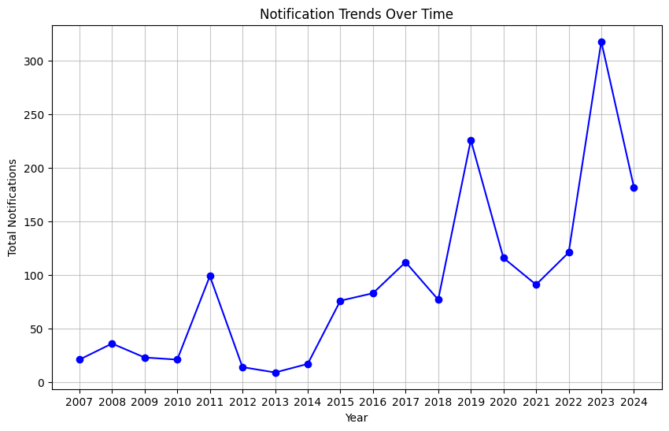

```python
plt.figure(figsize=(10, 6))

plt.plot(yearly_counts.index, yearly_counts.values, marker='o', linestyle='-', color = "b")

#Adding titles and labels
plt.title("Notification Trends Over Time")
plt.xlabel("Year")
plt.ylabel("Total Notifications")

#Only int in x axis
plt.xticks(yearly_counts.index)

#Grid
plt.grid(True, linestyle = "-", alpha = 0.7)

plt.show()
```

Se observa una tendencia general al alza en los casos reportados de efermedades a lo largo del tiempo, aunque con picks importantes entre años. En los primeros años (2007–2014) los valores se mantienen relativamente bajos e inestables. A partir de 2015 comienza un crecimiento sostenido con picks más agresivos que los años previos. Destacan aumentos fuertes en 2019 y 2023. Este último presenta el valor más alto. También se aprecia una caída en 2020–2021, posiblemente asociada a efectos de la pandemia. En general, el patrón sugiere un aumento en la detección o incidencia de enfermedades en los últimos años.

### A.1.2 Trend by nationality

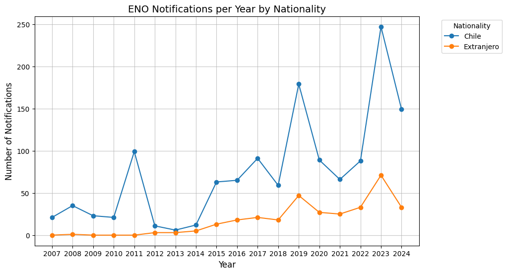

```python
#
yearly_counts_nat = pd.crosstab(eno_com["anho_notificacion"], eno_com["nacionalidad"])
#Adding the figure
plt.figure(figsize=(10, 6))
#
yearly_counts_nat.plot(kind = "line", marker = "o", ax = plt.gca())

# Ensure the X-axis only shows whole years
plt.xticks(yearly_counts_nat.index)
#Adding grid for better visualization
plt.grid(True, linestyle='-', alpha=0.7)

# 4. Add titles and labels
plt.title('ENO Notifications per Year by Nationality', fontsize=14)
plt.xlabel('Year', fontsize=12)
plt.ylabel('Number of Notifications', fontsize=12)
plt.legend(title="Nationality", bbox_to_anchor=(1.05, 1), loc='upper left')

plt.show()
```

## A.2 Disease Profiles (1.5 pts)

### A.2.1 Top diseases overall

We identify the 10 most frequently reported diseases in the selected comunas.

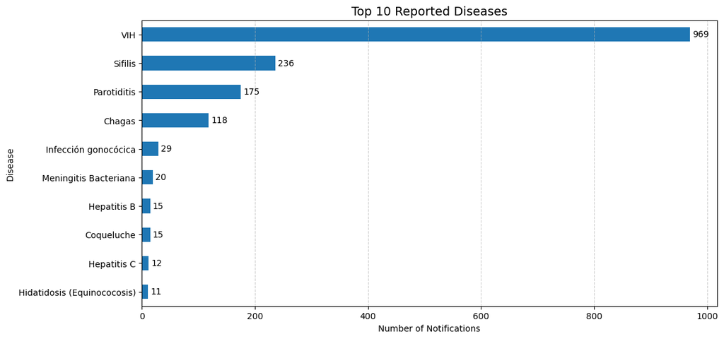

```python
top10 = eno_com["ENO"].value_counts().head(10)

plt.figure(figsize=(12,6))
ax = top10.sort_values().plot(kind="barh")

for container in ax.containers:
    ax.bar_label(container, fmt='%d', label_type='edge', padding=3)

plt.title("Top 10 Reported Diseases", fontsize=14)
plt.xlabel("Number of Notifications")
plt.ylabel("Disease")
plt.grid(axis='x', linestyle='--', alpha=0.6)

plt.show()
```

El gráfico identifica las 10 enfermedades con mayor número de notificaciones en las comunas de estudio.

VIH, Sífilis y Parotiditis ocupan los primeros lugares.VIH tiene una gran diferencia de casos en comparación con las demás enfermedades (aprox. 700 casos con la segunda más notificada).

Se puede inferir que es la enfermedad que más afecta a la población de las comunas estudiadas.

### A.2.2 Disease profiles by nationality

We compare the proportion of Chilean and foreign cases for the top 5 diseases.

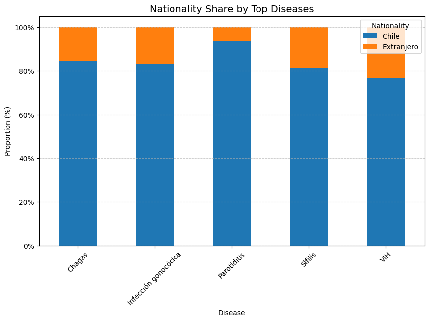

```python
from matplotlib.ticker import PercentFormatter

top5 = eno_com["ENO"].value_counts().head(5).index

df_top5 = eno_com[eno_com["ENO"].isin(top5)]

share = pd.crosstab(df_top5["ENO"], df_top5["nacionalidad"], normalize="index")

plt.figure(figsize=(10,6))
ax = share.plot(kind="bar", stacked=True, ax=plt.gca())

# Formato y-axis para mostrar porcentajes
ax.yaxis.set_major_formatter(PercentFormatter(xmax=1))

plt.title("Nationality Share by Top Diseases", fontsize=14)
plt.xlabel("Disease")
plt.ylabel("Proportion (%)") # Updated label
plt.xticks(rotation=45)
plt.legend(title="Nationality")

plt.grid(axis='y', linestyle='--', alpha=0.6)

plt.show()
```

Se observa la proporción de extrangeros según el top 5 enfermedades con más notificaciones.

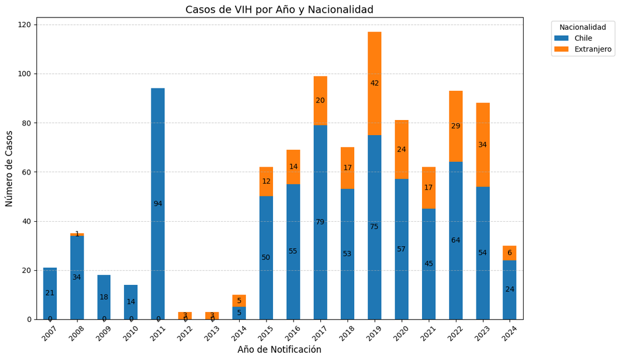

```python
from matplotlib.ticker import PercentFormatter

# Filter for VIH cases
df_vih = eno_com[eno_com["ENO"] == "VIH"]

# Group by year and nationality, then calculate counts and unstack
vih_yearly_nationality = pd.crosstab(
    df_vih["anho_notificacion"],
    df_vih["nacionalidad"]
)

# Calculate proportions per year
vih_yearly_nationality_prop = vih_yearly_nationality.apply(lambda x: x / x.sum(), axis=1)

# Plotting the stacked bar chart for raw counts
plt.figure(figsize=(12, 7))
ax_counts = vih_yearly_nationality.plot(kind='bar', stacked=True, ax=plt.gca())
for container in ax_counts.containers:
    ax_counts.bar_label(container, fmt='%d', label_type='center')

plt.title('Casos de VIH por Año y Nacionalidad', fontsize=14)
plt.xlabel('Año de Notificación', fontsize=12)
plt.ylabel('Número de Casos', fontsize=12)
plt.xticks(rotation=45)
plt.legend(title='Nacionalidad', bbox_to_anchor=(1.05, 1), loc='upper left')
plt.grid(axis='y', linestyle='--', alpha=0.6)

plt.tight_layout()
plt.show()
```

Se observa como aumentan a partir de 2015 los casos de VIH. Luego en 2019 se observa una tendencia a la baja.

Previo a 2015 se observan menos casos con un pick en 2011. Posteriormente no se reportan casos de chilenos contagiados y solamente extranjeros.

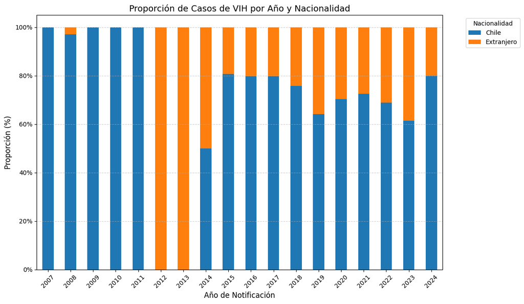

```python
vih_yearly_nationality_prop = vih_yearly_nationality.apply(lambda x: x / x.sum(), axis=1)

plt.figure(figsize=(12, 7))
ax = vih_yearly_nationality_prop.plot(kind='bar', stacked=True, ax=plt.gca())

# Format y-axis to show percentages
ax.yaxis.set_major_formatter(PercentFormatter(xmax=1))

plt.title('Proporción de Casos de VIH por Año y Nacionalidad', fontsize=14)
plt.xlabel('Año de Notificación', fontsize=12)
plt.ylabel('Proporción (%)', fontsize=12)
plt.xticks(rotation=45)
plt.legend(title='Nacionalidad', bbox_to_anchor=(1.05, 1), loc='upper left')
plt.grid(axis='y', linestyle='--', alpha=0.6)

plt.tight_layout()
plt.show()
```

No se observa una tendencia en relación a extranjeros y chilenos contagiados, si no que se mantiene más bien general.

### A.2.3 Age-group distribution for the top disease

We analyze the age distribution of the most common disease, split by nationality.

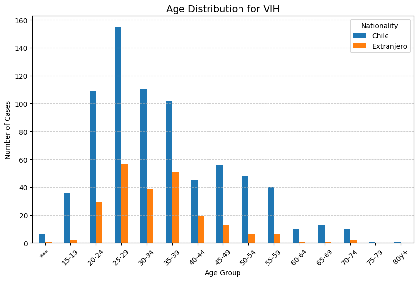

```python
top_disease = eno_com["ENO"].value_counts().idxmax()

df_top = eno_com[eno_com["ENO"] == top_disease]

age_dist = pd.crosstab(df_top["grupo_edad"], df_top["nacionalidad"])

plt.figure(figsize=(10,6))
age_dist.plot(kind="bar", ax=plt.gca())

plt.title(f"Age Distribution for {top_disease}", fontsize=14)
plt.xlabel("Age Group")
plt.ylabel("Number of Cases")
plt.xticks(rotation=45)
plt.legend(title="Nationality")

plt.grid(axis='y', linestyle='--', alpha=0.6)

plt.show()
```

La distribución por edad para la enfermedad más común (VIH) muestra que, en la población chilena de Lo Prado y Pudahuel, las notificaciones se concentran en adulto joven y adultos, lo cual es coherente con su mediana de edad más alta (37-41 años). En contraste, la población extranjera presenta un perfil más joven, con una concentración notoria en los grupos de 25 a 40 años, reflejando la estructura demográfica de este grupo en la Tarea 1 (mediana de 33-34 años). Esta diferencia sugiere que, mientras en los chilenos la vigilancia epidemiológica cubre todo el ciclo vital, en extranjeros está fuertemente ligada a la población en edad laboral activa.

## A.3 Spatial Vielw (0.5 pts)

### A.3.1 Notification counts by comuna

We compute the total number of notifications per comuna.

```
comuna_name
Pudahuel    1051
Lo Prado     591
Name: count, dtype: int64
```

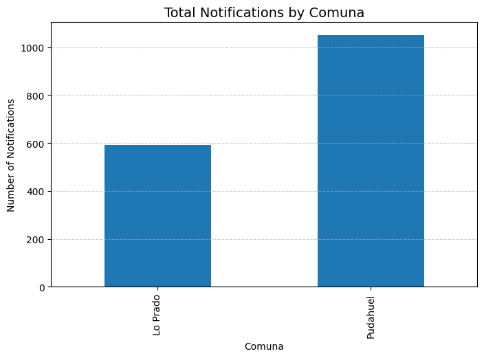

```python
comuna_name_map = {
    "13117": "Lo Prado",
    "13124": "Pudahuel"
}
eno_com["comuna_name"] = eno_com["codigo_comuna_residencia"].map(comuna_name_map)
print(eno_com["comuna_name"].value_counts())

comuna_counts = eno_com.groupby("comuna_name").size()


plt.figure(figsize=(8,5))
comuna_counts.plot(kind="bar")

plt.title("Total Notifications by Comuna", fontsize=14)
plt.xlabel("Comuna")
plt.ylabel("Number of Notifications")

plt.grid(axis='y', linestyle='--', alpha=0.6)

plt.show()
```

## A.4 Comuna-Level ENO Summary Table (1 pt)

### A.4 Comuna-Level ENO Summary Table

We build a comuna-level summary table including total notifications, nationality breakdown, top diseases, and crude notification rates.

```python
# Cargar datos de Tarea 1
t1 = pd.read_csv("/content/drive/MyDrive/Ramo_IELE756/tarea1_summary.csv")

# Renombrar para facilitar merge
t1 = t1.rename(columns={"comuna": "codigo_comuna_residencia"})

# Convertir codigo_comuna_residencia a string en t1 para el merge
t1["codigo_comuna_residencia"] = t1["codigo_comuna_residencia"].astype(str)

# Función resumen
def build_eno_summary(df):
    return pd.Series({
        "eno_total": len(df),
        "eno_chilean": (df["nacionalidad"] == "Chile").sum(),
        "eno_foreign": (df["nacionalidad"] == "Extranjero").sum(),
        "eno_desconocido": (df["nacionalidad"] == "Desconocido").sum(),
        "eno_top3_diseases": ", ".join(df["ENO"].value_counts().head(3).index)
    })

eno_summary = eno_com.groupby("codigo_comuna_residencia").apply(build_eno_summary).reset_index()

# Merge con población
eno_summary = eno_summary.merge(t1[["codigo_comuna_residencia", "Comuna Nombre", "pop_total"]],
                                on="codigo_comuna_residencia", how="left")

# Tasa por 10.000
eno_summary["eno_rate_per_10k"] = (eno_summary["eno_total"] / eno_summary["pop_total"]) * 10000

eno_summary.to_csv("tarea2_eno_summary.csv", index=False)
eno_summary
```

|  | codigo_comuna_residencia | eno_total | eno_chilean | eno_foreign | eno_desconocido | eno_top3_diseases | Comuna Nombre | pop_total | eno_rate_per_10k |
| --- | --- | --- | --- | --- | --- | --- | --- | --- | --- |
| 0 | 13117 | 591 | 442 | 149 | 0 | VIH, Sifilis, Parotiditis | Lo Prado | 91290.0 | 64.738745 |
| 1 | 13124 | 1051 | 882 | 169 | 0 | VIH, Sifilis, Parotiditis | Pudahuel | 227820.0 | 46.132912 |

**Análisis de Notificaciones (ENO)**

**Carga de Enfermedad:** Lo Prado presenta una mayor vulnerabilidad epidemiológica con una tasa de 64.7 por cada 10.000 habitantes, superando los 46.1 de Pudahuel.

**Representación Extranjera:** En ambas comunas, la proporción de notificaciones en extranjeros supera su peso poblacional declarado en la Tarea 1. En Lo Prado representan el 25.2% de los casos (frente al 13.2% de población) y en Pudahuel el 16.1% (frente al 6.7%).

**Perfil Común:** El predominio de VIH, Sífilis y Parotiditis en ambas zonas sugiere una concentración de la vigilancia en salud sexual y virus estacionales.

**Limitación de Datos:** Estas cifras son subestimaciones obligatorias, ya que el 45% de la base original está anonimizada (*****) y no pudo ser asignada a ninguna comuna.

# PART B: GRD – Hospital Discharges (5 pts)

## B.0 Data Loading & Cleaning (1.5 pts)

### B.0.1 Load GRD files for 2022–2024

We load hospital discharge data for 2022-2024

```python
import pandas as pd
import os

# Columnas necesarias
grD_cols = ["COMUNA", "NACIONALIDAD", "SEXO", "FECHA_NACIMIENTO",
            "FECHA_INGRESO", "FECHAALTA", "TIPOALTA",
            "DIAGNOSTICO1", "DIAGNOSTICO2", "IR_29301_SEVERIDAD", "IR_29301_MORTALIDAD",
            "IR_29301_COD_GRD", "TIPO_INGRESO", "ESPECIALIDADINTERVENCION"]

# Ruta Drive
base_path = "/content/drive/MyDrive/Ramo_IELE756/"

frames = []

for año in [2022, 2023, 2024]:

    # Cambiamos para leer directamente el archivo txt, no desde un zip
    file_path = f"{base_path}GRD_PUBLICO_{año}.txt"

    print(f"\nProcesando año {año}...")

    try:
        # Usar chunksize para archivos grandes y procesar por fragmentos
        chunks = pd.read_csv(file_path,
                             sep="|",
                             encoding="latin-1", # Usar latin-1 para todos los años
                             encoding_errors='replace', # Maneja caracteres inválidos
                             engine='python', # Requerido para on_bad_lines
                             on_bad_lines='warn', # Advierte sobre líneas incorrectas en lugar de errores
                             chunksize=300000)

        for i, chunk in enumerate(chunks):
            # Limpieza agresiva de nombres de columnas: strip, upper, y quitar bytes nulos
            chunk.columns = [str(col).upper().strip().replace('\x00', '') for col in chunk.columns]

            cols_to_keep = [col.upper() for col in grD_cols]
            cols_available = [c for c in cols_to_keep if c in chunk.columns]

            if not cols_available:
                print(f"Advertencia: Para el año {año}, fragmento {i+1}, no se encontraron columnas relevantes. Columnas detectadas: {chunk.columns.tolist()}")
                continue # Saltamos este chunk si no tiene columnas relevantes

            chunk = chunk[cols_available].copy()
            chunk["año"] = año
            frames.append(chunk)

            print(f"Procesado fragmento {i+1} para el año {año}. Filas en el fragmento: {len(chunk)}")

    except FileNotFoundError:
        print(f"Advertencia: El archivo '{file_path}' no se encontró. Saltando el año {año}.")
    except Exception as e:
        print(f"Ocurrió un error al procesar el año {año}: {e}")

# unir todo
if frames:
    grd = pd.concat(frames, ignore_index=True)

    # Limpiar la columna 'COMUNA' después de la concatenación
    grd['COMUNA'] = grd['COMUNA'].astype(str).str.replace('\x00', '', regex=False).str.strip().str.upper()

    print(f"Total discharges (3 years): {len(grd):,}")
    print(grd.head())
    print("Columnas finales:\n", grd.columns.tolist())
else:
    print("No se cargaron datos para ningún año.")
```

```
Procesando año 2022...
```

```
Procesado fragmento 1 para el año 2022. Filas en el fragmento: 299999
Procesado fragmento 2 para el año 2022. Filas en el fragmento: 300000
Procesado fragmento 3 para el año 2022. Filas en el fragmento: 300000
Procesado fragmento 4 para el año 2022. Filas en el fragmento: 300000
Procesado fragmento 5 para el año 2022. Filas en el fragmento: 300000
Procesado fragmento 6 para el año 2022. Filas en el fragmento: 300000
Procesado fragmento 7 para el año 2022. Filas en el fragmento: 65682

Procesando año 2023...
Procesado fragmento 1 para el año 2023. Filas en el fragmento: 300000
Procesado fragmento 2 para el año 2023. Filas en el fragmento: 300000
Procesado fragmento 3 para el año 2023. Filas en el fragmento: 300000
Procesado fragmento 4 para el año 2023. Filas en el fragmento: 300000
Procesado fragmento 5 para el año 2023. Filas en el fragmento: 300000
Procesado fragmento 6 para el año 2023. Filas en el fragmento: 300000
Procesado fragmento 7 para el año 2023. Filas en el fragmento: 279176

Procesando año 2024...
Procesado fragmento 1 para el año 2024. Filas en el fragmento: 300000
Procesado fragmento 2 para el año 2024. Filas en el fragmento: 300000
Procesado fragmento 3 para el año 2024. Filas en el fragmento: 300000
Procesado fragmento 4 para el año 2024. Filas en el fragmento: 185813
Total discharges (3 years): 5,030,670
         COMUNA NACIONALIDAD           SEXO       FECHA_NACIMIENTO  \
0          NONE         None           None                   None
1  SAN FERNANDO  CHILE  HOMBRE  2022-01-02
2          NONE         None           None                   None
3       COPIAPO  CHILE    MUJER  1981-07-05
4          NONE         None           None                   None

           FECHA_INGRESO              FECHAALTA             TIPOALTA  \
0                   None                   None                 None
1  2022-08-01  2022-08-09  DOMICILIO
2                   None                   None                 None
3  2022-11-01  2022-11-04  DOMICILIO
4                   None                   None                 None

  DIAGNOSTICO1 DIAGNOSTICO2 IR_29301_SEVERIDAD IR_29301_MORTALIDAD  \
0         None         None               None                None
1  Q03.9      H55                3                 1
2         None         None               None                None
3  I47.1      I10                1                 1
4         None         None               None                None

  IR_29301_COD_GRD           TIPO_INGRESO   ESPECIALIDADINTERVENCION   año
0             None                   None                       None  2022
1    011113      URGENCIA  NEUROCIRUGÍA  2022
2             None                   None                       None  2022
3    051401  PROGRAMADA                            2022
4             None                   None                       None  2022
Columnas finales:
 ['COMUNA', 'NACIONALIDAD', 'SEXO', 'FECHA_NACIMIENTO', 'FECHA_INGRESO', 'FECHAALTA', 'TIPOALTA', 'DIAGNOSTICO1', 'DIAGNOSTICO2', 'IR_29301_SEVERIDAD', 'IR_29301_MORTALIDAD', 'IR_29301_COD_GRD', 'TIPO_INGRESO', 'ESPECIALIDADINTERVENCION', 'año']
```

### B.0.2 Filtering to our comunas

Número de hospitalizaciones por año en Lo Prado y Pudahuel.

```python
# nombres en mayúscula
MY_COMUNA_NAMES = ["LO PRADO", "PUDAHUEL"]

grd_com = grd[grd["COMUNA"].isin(MY_COMUNA_NAMES)]

print("Rows in my comunas:", len(grd_com))

# Casos por año
print(grd_com.groupby("año").size())
```

```
Rows in my comunas: 49213
año
2022    15061
2023    17084
2024    17068
dtype: int64
```

**Comentario:**

En las comunas analizadas se registran 49.213 hospitalizaciones. Se observan un aumento desde 2022 (15.061 casos) a 2023 (17.084 casos), lo que indica un incremento en la actividad hospitalaria (+2023 hospitalizaciones).

### B.0.3 Compute length of stay

Distribución de media, mediana, mínimo, máximo, de los pacientes hospitalizados

```python
grd_com["FECHA_INGRESO"] = pd.to_datetime(grd_com["FECHA_INGRESO"], format='mixed', dayfirst=True)
grd_com["FECHAALTA"] = pd.to_datetime(grd_com["FECHAALTA"], format='mixed', dayfirst=True)

grd_com["los"] = (grd_com["FECHAALTA"] - grd_com["FECHA_INGRESO"]).dt.days

# Filtrar errores
neg = (grd_com["los"] < 0).sum()
print("Rows removed (los < 0):", neg)

grd_com = grd_com[grd_com["los"] >= 0]

print(grd_com["los"].describe())
```

```
Rows removed (los < 0): 0
count    17079.000000
mean         6.000644
std         12.290447
min          0.000000
25%          1.000000
50%          2.000000
75%          6.000000
max        305.000000
Name: los, dtype: float64
```

### B.0.4 Create nationality grouping

```python
grd_com["nat_group"] = grd_com["NACIONALIDAD"].apply(
    lambda x: "Chileno" if x == "CHILE" else "Extranjero"
)

grd_com["nat_group"].value_counts()
```

| nat_group | count |
| --- | --- |
| Chileno | 15774 |
| Extranjero | 1305 |

**dtype:** int64

### B.0.5 Join diagnoses to CIE-10

```python
cie10 = pd.read_excel("/content/drive/MyDrive/Ramo_IELE756/CIE-10.xlsx", sheet_name="CIE 10")

grd_com = grd_com.merge(
    cie10[["Código", "Descripción", "Capítulo"]].drop_duplicates("Código"),
    left_on="DIAGNOSTICO1", right_on="Código", how="left"
)

print("Unmatched rows:", grd_com["Capítulo"].isna().sum())
```

```
Unmatched rows: 11
```

# B.1 Diagnostic Profile

### B.1.1 Top diagnostic chapters

Se identifican los principales grupos de enfermedades en las hospitalizaciones.

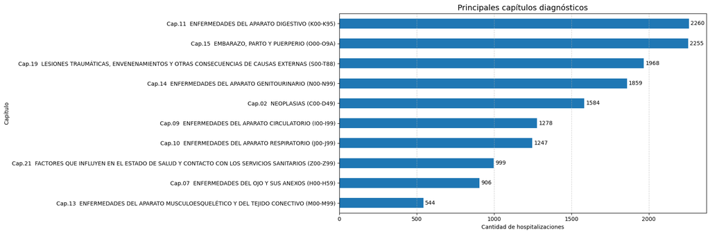

```python
top_chapters = grd_com["Capítulo"].value_counts().head(10)

plt.figure(figsize=(18,6))
ax = top_chapters.sort_values().plot(kind="barh")

for container in ax.containers:
    ax.bar_label(container, fmt='%d', label_type='edge', padding=3)

plt.title("Principales capítulos diagnósticos", fontsize=14)
plt.xlabel("Cantidad de hospitalizaciones")
plt.ylabel("Capítulo")
plt.grid(axis='x', linestyle='--', alpha=0.6)

plt.tight_layout()
plt.show()
```

En las comunas de estudio predominan los capítulos 15 y 11 com embarazo, parto y puerperio, enfermedades del aparato digestivo como capitulos diagnósticos con mayor cantidad de hospitalizaciones. Luego con cerca de 2000 hospitalizaciones predominan las lesiones traumáticas, envenenamientos y otraas consecuencias de causas externas. En menor medida de los capítulos de enfermedades se encuentran las enfermedades del ojo y del aparato musculoesquelético y del tejido conectivo.

### B.1.2 Top specific diagnoses

Se analizan las enfermedades específicas más frecuentes.

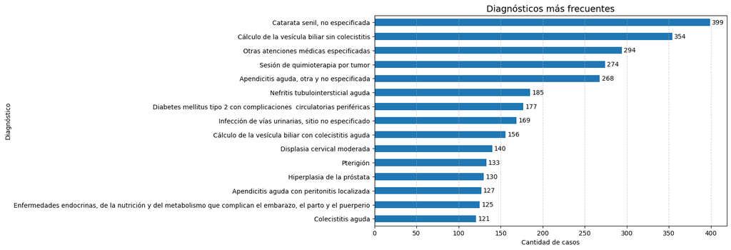

```python
top_diag = grd_com["Descripción"].value_counts().head(15)

plt.figure(figsize=(10,6))
ax = top_diag.sort_values().plot(kind="barh")

for container in ax.containers:
    ax.bar_label(container, fmt='%d', label_type='edge', padding=3)

plt.title("Diagnósticos más frecuentes", fontsize=14)
plt.xlabel("Cantidad de casos")
plt.ylabel("Diagnóstico")
plt.grid(axis='x', linestyle='--', alpha=0.6)

plt.show()
```

Los diagnósicos más frecuentes son catarata senil (no especificada), cálculo de la vesícula biliar (sin colecistitis) y otras atenciones médicas especificadas. Todas presentan aproximadamente más de 300 casos, teniendo el mayor número el diagnóstico de catarata, con una diferencia de más de 100 casos con respecto a "otras atenciones médicas".

### B.1.3 Diagnostic chapters by nationality

Se compara la distribución de enfermedades entre chilenos y extranjeros.

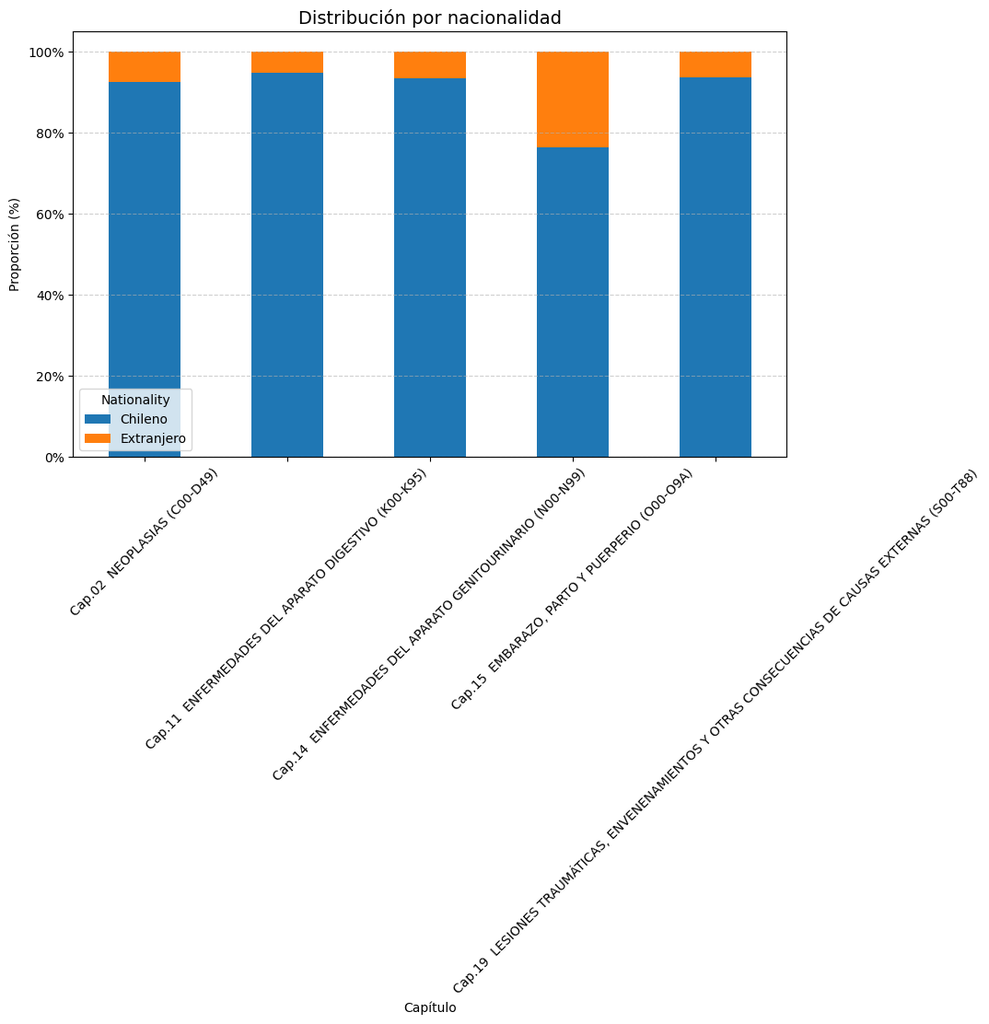

```python
from matplotlib.ticker import PercentFormatter

# Re-add nat_group creation in case it was lost or not executed
if "nat_group" not in grd_com.columns:
    grd_com["nat_group"] = grd_com["NACIONALIDAD"].apply(
        lambda x: "Chilean" if x == "CHILE" else "Foreign"
    )

top5 = grd_com["Capítulo"].value_counts().head(5).index

df_top = grd_com[grd_com["Capítulo"].isin(top5)]

share = pd.crosstab(df_top["Capítulo"], grd_com["nat_group"], normalize="index")

plt.figure(figsize=(10,6))
ax = share.plot(kind="bar", stacked=True, ax=plt.gca())

# Format y-axis to show percentages
ax.yaxis.set_major_formatter(PercentFormatter(xmax=1))

plt.title("Distribución por nacionalidad", fontsize=14)
plt.ylabel("Proporción (%)") # Updated label
plt.xticks(rotation=45)
plt.legend(title="Nationality")

plt.grid(axis='y', linestyle='--', alpha=0.6)

plt.show()
```

```python
# Ensure 'nat_group' column exists
if "nat_group" not in grd_com.columns:
    grd_com["nat_group"] = grd_com["NACIONALIDAD"].apply(
        lambda x: "Chilean" if x == "CHILE" else "Foreign"
    )

# Calculate the percentage of Chilean and Foreign patients for each diagnostic chapter
chapter_nationality_percentage = pd.crosstab(
    grd_com["Capítulo"],
    grd_com["nat_group"],
    normalize="index"
)

# Display the result, formatted as percentages
display(chapter_nationality_percentage.style.format("{:.2%}"))
```

| nat_group Capítulo | Chileno | Extranjero |
| --- | --- | --- |
| Cap.01 CIERTAS ENFERMEDADES INFECCIOSAS Y PARASITARIAS (A00-B99) | 94.17% | 5.83% |
| Cap.02 NEOPLASIAS (C00-D49) | 92.49% | 7.51% |
| Cap.03 ENFERMEDADES DE LA SANGRE Y ÓRGANOS HEMATOPOYÉTICOS Y CIERTOS TRASTORNOS QUE AFECTAN AL MECANISMO INMUNOLÓGICO (D50-D89) | 86.21% | 13.79% |
| Cap.04 ENFERMEDADES ENDOCRINAS, NUTRICIONALES Y METABÓLICAS (E00-E89) | 97.02% | 2.98% |
| Cap.05 TRASTORNOS MENTALES Y DE COMPORTAMIENTO (F01-F99) | 97.48% | 2.52% |
| Cap.06 ENFERMEDADES DEL SISTEMA NERVIOSO (G00-G99) | 97.21% | 2.79% |
| Cap.07 ENFERMEDADES DEL OJO Y SUS ANEXOS (H00-H59) | 94.92% | 5.08% |
| Cap.08 ENFERMEDADES DEL OÍDO Y DE LA APÓFISIS MASTOIDES (H60-H95) | 97.44% | 2.56% |
| Cap.09 ENFERMEDADES DEL APARATO CIRCULATORIO (I00-I99) | 97.65% | 2.35% |
| Cap.10 ENFERMEDADES DEL APARATO RESPIRATORIO (J00-J99) | 96.79% | 3.21% |
| Cap.11 ENFERMEDADES DEL APARATO DIGESTIVO (K00-K95) | 94.73% | 5.27% |
| Cap.12 ENFERMEDADES DE LA PIEL Y DEL TEJIDO SUBCUTÁNEO (L00-L99) | 93.27% | 6.73% |
| Cap.13 ENFERMEDADES DEL APARATO MUSCULOESQUELÉTICO Y DEL TEJIDO CONECTIVO (M00-M99) | 96.51% | 3.49% |
| Cap.14 ENFERMEDADES DEL APARATO GENITOURINARIO (N00-N99) | 93.49% | 6.51% |
| Cap.15 EMBARAZO, PARTO Y PUERPERIO (O00-O9A) | 76.32% | 23.68% |
| Cap.16 CIERTAS AFECCIONES ORIGINADAS EN EL PERÍODO PERINATAL (P00-P96) | 99.72% | 0.28% |
| Cap.17 MALFORMACIONES CONGÉNITAS, DEFORMIDADES Y ANOMALÍAS CROMOSÓMICAS (Q00-Q99) | 92.07% | 7.93% |
| Cap.18 SÍNTOMAS, SIGNOS Y RESULTADOS ANORMALES DE PRUEBAS COMPLEMENTARIAS, NO CLASIFICADOS BAJO OTRO CONCEPTO (R00-R99) | 95.83% | 4.17% |
| Cap.19 LESIONES TRAUMÁTICAS, ENVENENAMIENTOS Y OTRAS CONSECUENCIAS DE CAUSAS EXTERNAS (S00-T88) | 93.60% | 6.40% |
| Cap.21 FACTORES QUE INFLUYEN EN EL ESTADO DE SALUD Y CONTACTO CON LOS SERVICIOS SANITARIOS (Z00-Z99) | 94.79% | 5.21% |
| Cap.22 CÓDIGOS PARA SITUACIONES ESPECIALES (U00-U99) | 96.97% | 3.03% |

Se muestra el porcentaje de pacientes chilenos y extranjeros para cada capítulo de diagnóstico (grupo principal de enfermedades).

## Lenght of Stay & Severity

### B.2.1 Length of stay by nationality

Se compara la duración de hospitalización entre grupos.

```python
grd_com.groupby("nat_group")["los"].mean()
```

| nat_group | los |
| --- | --- |
| Chileno | 6.137695 |
| Extranjero | 4.344061 |

**dtype:** float64

### B.2.2 Severity distribution

Se analiza la gravedad de los casos hospitalarios.

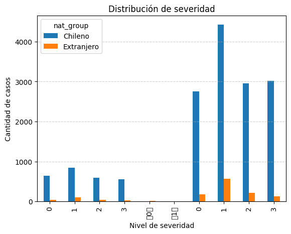

```python
pd.crosstab(grd_com["IR_29301_SEVERIDAD"], grd_com["nat_group"]).plot(kind="bar")

plt.title("Distribución de severidad")
plt.xlabel("Nivel de severidad")
plt.ylabel("Cantidad de casos")
plt.grid(axis='y', linestyle='--', alpha=0.6)

plt.show()
```

La mayoría de los casos se concentra en niveles medios de severidad con mas 4000 casos. Luego le sigue aproximadamente 3200 casos en niveles críticos para el grupo de chilenos. No así para los extranjeros, que concentran su mayor candidad de casos en niveles medio-bajo.

### B.2.3 Discharge type

Se analiza el tipo de egreso hospitalario.

```python
grd_com["TIPOALTA"].value_counts()

mortality = (grd_com["TIPOALTA"] == "FALLECIDO").mean()
print("Tasa de mortalidad:", mortality)
```

```
Tasa de mortalidad: 0.0284559985947655
```

**Comentario:**  
La tasa de mortalidad es relativamente baja, indicando que los son resultados favorables en la mayoría de las hospitalizaciones.

### B.3 Spatial view

Visualización de hospitalizaciones por comuna.

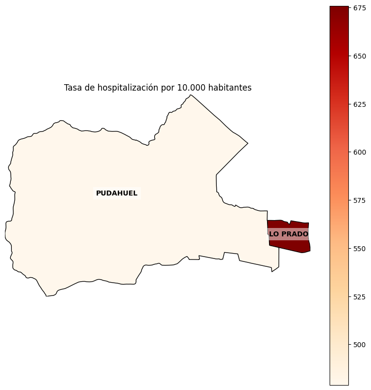

```python
import geopandas as gpd
import matplotlib.pyplot as plt

comunas_gdf = gpd.read_file("/content/drive/MyDrive/Ramo_IELE756/comunas.shp")

# Estandarizar la columna del nombre de la comuna en comunas_gdf a 'COMUNA'
# Comprobar si hay nombres de columnas comunes y renombrarlos a 'COMUNA'
if 'NOM_COMUNA' in comunas_gdf.columns:
    comunas_gdf = comunas_gdf.rename(columns={'NOM_COMUNA': 'COMUNA'})
elif 'NAME_COM' in comunas_gdf.columns:
    comunas_gdf = comunas_gdf.rename(columns={'NAME_COM': 'COMUNA'})
elif 'nombre_com' in comunas_gdf.columns:
    comunas_gdf = comunas_gdf.rename(columns={'nombre_com': 'COMUNA'})
elif 'Comuna' in comunas_gdf.columns:
    comunas_gdf = comunas_gdf.rename(columns={'Comuna': 'COMUNA'})

# Asegurar que la columna 'COMUNA' en comunas_gdf exista y esté en mayúsculas para la coincidencia
if 'COMUNA' in comunas_gdf.columns:
    comunas_gdf['COMUNA'] = comunas_gdf['COMUNA'].str.upper()
else:
    print("Advertencia: No se encontró una columna adecuada para el nombre de la comuna en comunas.shp. La fusión podría fallar.")
    print("Columnas en comunas_gdf:", comunas_gdf.columns.tolist()) # Añadido para diagnóstico

# Preparación de datos
hosp_counts = grd_com.groupby("COMUNA").size().reset_index(name="hospitalizaciones")

t1["Comuna Nombre"] = t1["Comuna Nombre"].str.upper()

df_map = hosp_counts.merge(t1, left_on="COMUNA", right_on="Comuna Nombre")
df_map["tasa_hosp"] = (df_map["hospitalizaciones"] / df_map["pop_total"]) * 10000

# Unión con el GeoDataFrame
map_data = comunas_gdf.merge(df_map, on="COMUNA", how="left")

# Creación del gráfico base
fig, ax = plt.subplots(figsize=(10, 10))
map_data.plot(column="tasa_hosp",
              cmap="OrRd",
              legend=True,
              edgecolor="black",
              ax=ax)


# Extraemos los límites geográficos de las comunas
bounds = map_data[map_data["COMUNA"].isin(["LO PRADO", "PUDAHUEL"])].total_bounds
ax.set_xlim(bounds[0] - 0.02, bounds[2] + 0.02)
ax.set_ylim(bounds[1] - 0.02, bounds[3] + 0.02)

# Etiquetado
for idx, row in map_data[map_data["COMUNA"].isin(["LO PRADO", "PUDAHUEL"])].iterrows():
    punto = row['geometry'].representative_point()
    ax.text(punto.x, punto.y, row["COMUNA"],
            fontsize=10, fontweight='bold', ha='center',
            bbox=dict(facecolor='white', alpha=0.5, edgecolor='none'))

plt.title("Tasa de hospitalización por 10.000 habitantes")
ax.set_axis_off()
plt.show()
```

En este mapa se puede ver la tasa de hospitalización por cada 10.000 habitantes para Pudahuel y Lo Prado. Se cruzaron los datos de altas hospitalarias (GRD) con el pop_total que se obtuvo en la Tarea 1.

Lo que más destaca es que "Lo Prado" tiene una tasa de hospitalización más alta. Considerando los datos de la entrega pasada, esta comuna también tenía mayor porcentaje de extranjeros, lo que podría explicar por qué su población requiere más servicios de salud pública en comparación con la otra.

La gran y notable diferencia entre ambas comunas, es la densidad de población existente en cada una, influenciada claramente por su área. Al Lo Prado tener una mayor densidad de personas, también influencia el resultado mostrado en este mapa.

## B.4 Comuna-Level GRD Summary Table

```python
import pandas as pd
import os

def build_grd_summary(group):

    # Totales por nacionalidad
    total = len(group)
    chilean = (group["nat_group"] == "Chileno").sum()
    foreign = (group["nat_group"] == "Extrangero").sum()
    pct_foreign = (foreign / total * 100) if total > 0 else 0

    # Estadía (Length of Stay)
    mean_los = group["los"].mean()
    mean_los_chilean = group[group["nat_group"] == "Chileno"]["los"].mean()
    mean_los_foreign = group[group["nat_group"] == "Extrangero"]["los"].mean()

    # Severidad (Promedio de IR_29301_SEVERIDAD)
    mean_severity = group["IR_29301_SEVERIDAD"].mean()

    # Tasa de mortalidad intrahospitalaria (% de TIPOALTA == "FALLECIDO")
    mortality_rate = (group["TIPOALTA"] == "FALLECIDO").mean() * 100

    # Top 3 Capítulos CIE-10 (Unidos por comas)
    top3_chapters = ", ".join(group["Capítulo"].value_counts().nlargest(3).index.astype(str))

    return pd.Series({
        "grd_total": total,
        "grd_chilean": chilean,
        "grd_foreign": foreign,
        "grd_pct_foreign": pct_foreign,
        "grd_mean_los": mean_los,
        "grd_mean_los_chilean": mean_los_chilean,
        "grd_mean_los_foreign": mean_los_foreign,
        "grd_mean_severity": mean_severity,
        "grd_mortality_rate": mortality_rate,
        "grd_top3_chapters": top3_chapters
    })

# Convertir 'IR_29301_SEVERIDAD' a tipo numérico antes de agrupar
grd_com["IR_29301_SEVERIDAD"] = pd.to_numeric(grd_com["IR_29301_SEVERIDAD"], errors='coerce')

# Generar el resumen desde los datos de GRD filtrados
grd_summary_base = grd_com.groupby("COMUNA").apply(build_grd_summary).reset_index()

# Cargar datos de la Tarea 1 para obtener códigos y población
t1_summary = pd.read_csv("/content/drive/MyDrive/Ramo_IELE756/tarea1_summary.csv")

# Preparar el merge: estandarizar nombres de comunas
t1_summary["nombre_comuna_upper"] = t1_summary["Comuna Nombre"].str.upper()

# Unir los datos de GRD con los de la Tarea 1
grd_summary = grd_summary_base.merge(
    t1_summary[["nombre_comuna_upper", "comuna", "Comuna Nombre", "pop_total"]],
    left_on="COMUNA",
    right_on="nombre_comuna_upper",
    how="left"
)

# Calcular la tasa de hospitalización por cada 10.000 habitantes
grd_summary["grd_rate_per_10k"] = (grd_summary["grd_total"] / grd_summary["pop_total"]) * 10000


grd_summary = grd_summary.rename(columns={
    "comuna": "codigo_comuna",
    "Comuna Nombre": "nombre_comuna"
})

cols_ordenadas = [
    "codigo_comuna", "nombre_comuna", "grd_total", "grd_chilean", "grd_foreign",
    "grd_pct_foreign", "grd_mean_los", "grd_mean_los_chilean", "grd_mean_los_foreign",
    "grd_mean_severity", "grd_mortality_rate", "grd_top3_chapters", "grd_rate_per_10k"
]

grD_summary = grd_summary[cols_ordenadas]

# Mostrar y guardar
display(grd_summary)

# Crear la carpeta 'output' si no existe
output_dir = "output"
if not os.path.exists(output_dir):
    os.makedirs(output_dir)

grD_summary.to_csv(os.path.join(output_dir, "tarea2_grd_summary.csv"), index=False)
```

|  | COMUNA | grd_total | grd_chilean | grd_foreign | grd_pct_foreign | grd_mean_los | grd_mean_los_chilean | grd_mean_los_foreign | grd_mean_severity | grd_mortality_rate | grd_top3_chapters | nombre_comuna_upper | codigo_comuna | nombre_comuna | pop_total | grd_rate_per_10k |
| --- | --- | --- | --- | --- | --- | --- | --- | --- | --- | --- | --- | --- | --- | --- | --- | --- |
| 0 | LO PRADO | 6169 | 5589 | 0 | 0.0 | 5.955584 | 6.091251 | NaN | 1.383804 | 3.063706 | Cap.11 ENFERMEDADES DEL APARATO DIGESTIVO (K0... | LO PRADO | 13117 | Lo Prado | 91290.0 | 675.758572 |
| 1 | PUDAHUEL | 10910 | 10185 | 0 | 0.0 | 6.026123 | 6.163181 | NaN | 1.483220 | 2.722273 | Cap.11 ENFERMEDADES DEL APARATO DIGESTIVO (K0... | PUDAHUEL | 13124 | Pudahuel | 227820.0 | 478.886840 |

Al comparar las dos comunas, se pueden obtener las siguientes conclusiones:

**Carga de Enfermedad (Tasas de Hospitalización):** Lo Prado tiene una tasa de hospitalización más alta que Pudahuel (675 vs 478.7 por cada 10.000 habitantes). Según lo visto en la Tarea 1, Lo Prado contiene una población con mayor edad mediana, lo que suele explicar una mayor necesidad de atención médica.

**Causas Principales (Capítulos Diagnósticos):**

- Para Lo Prado, los 3 capítulos diagnósticos más frecuentes son: `Cap.11 ENFERMEDADES DEL APARATO DIGESTIVO (K00-K95)`, `Cap.15 EMBARAZO, PARTO Y PUERPERIO (O00-O9A)` y `Cap.19 LESIONES TRAUMÁTICAS, ENVENENAMIENTOS Y OTRAS CONSECUENCIAS DE CAUSAS EXTERNAS (S00-T88)`.
- Para Pudahuel, los 3 capítulos diagnósticos más frecuentes son: `Cap.11 ENFERMEDADES DEL APARATO DIGESTIVO (K00-K95)`, `Cap.15 EMBARAZO, PARTO Y PUERPERIO (O00-O9A)` y `Cap.14 ENFERMEDADES DEL APARATO GENITOURINARIO (N00-N99)`. Es común en el sistema público que `Cap.15 EMBARAZO, PARTO Y PUERPERIO` sea una causa principal. En Pudahuel, las enfermedades genitourinarias aparecen con fuerza, mientras que en Lo Prado destacan más las lesiones traumáticas y envenenamientos, lo que refuerza la idea de una población con necesidades de salud distintas.

```python
# Guardar resumen ENO
eno_summary.to_csv("output/tarea2_eno_summary.csv", index=False)

# Guardar resumen GRD
grd_summary.to_csv("output/tarea2_grd_summary.csv", index=False)

print("Archivos guardados en la carpeta output.")
```

```
Archivos guardados en la carpeta output.
```